# load library

```r
library(ggplot2)
library(dplyr)
library(gridExtra)
library(grid)
library(lattice)
library(ggpubr)
library(DataExplorer)
library(cluster)
library(factoextra)
library(tidyr)
library(FactoMineR)
library(tidyverse)
library(corrplot)
library(gridExtra)
library(GGally)
library(factoextra)
```

### Importing the datasets

```r
airline <- read.csv("C:/Users/admin/Desktop/Lab1/skytrax-reviews-dataset-master/skytrax-reviews-dataset-master/data/airline.csv")
Long.haul.Busineess.Class <- read.csv("C:/Users/admin/Desktop/Lab1/Data de heny/Long haul Busineess Class.csv")
Short_haul.first.buisiness.class <- read.csv("C:/Users/admin/Desktop/Lab1/Data de heny/Short_haul first-buisiness class.csv")
```

### data cleaning

we will only need airline name ,cabin flown seat comfort rating entretanment value mony staff rating ground service rating recommended overall_rating wifi rating

```r
quanti<-airline[,c(1,10,12,13,14,15,16,17,18,19,20)]
```

lets view our missing data

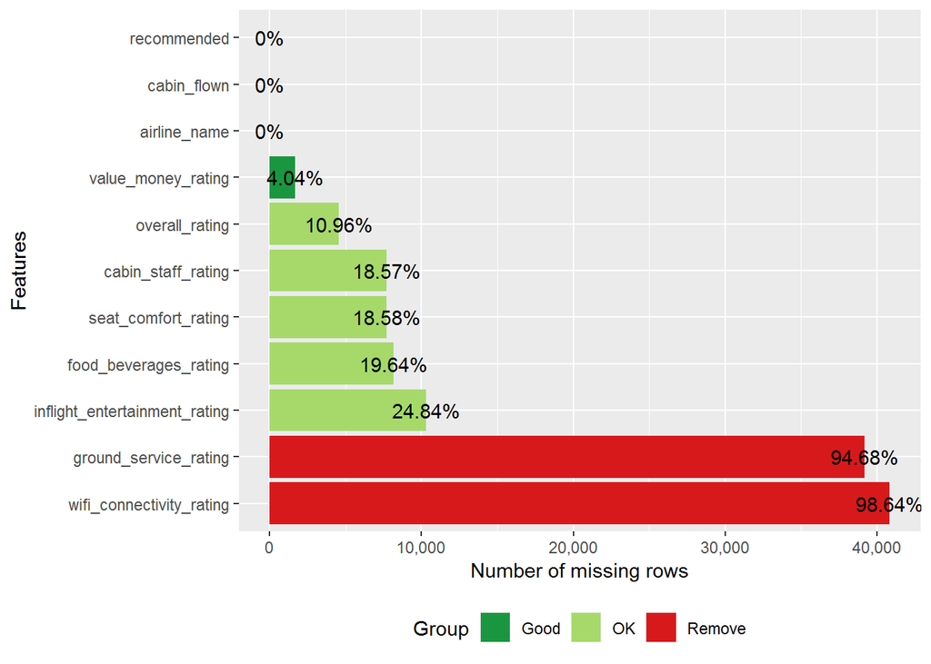

```r
plot_missing(quanti)
```

##### we notice that ground service and wifi connectivte have a very high percentage of missing data

so it is for the best if they are removed

```r
quanti<-airline[,c(1,10,12,13,14,15,16,19,20)]
```

lets do a little summary for our data

```r
summary(quanti)
```

```
##            airline_name            cabin_flown    overall_rating
##  spirit-airlines :  990                  : 2876   Min.   : 1.00
##  british-airways :  901   Business Class : 6347   1st Qu.: 3.00
##  united-airlines :  840   Economy        :29784   Median : 7.00
##  jet-airways     :  727   First Class    :  879   Mean   : 6.04
##  air-canada-rouge:  715   Premium Economy: 1510   3rd Qu.: 9.00
##  emirates        :  691                           Max.   :10.00
##  (Other)         :36532                           NA's   :4535
##  seat_comfort_rating cabin_staff_rating food_beverages_rating
##  Min.   :0.000       Min.   :0.000      Min.   :0.000
##  1st Qu.:2.000       1st Qu.:2.000      1st Qu.:1.000
##  Median :3.000       Median :4.000      Median :3.000
##  Mean   :3.095       Mean   :3.319      Mean   :2.806
##  3rd Qu.:4.000       3rd Qu.:5.000      3rd Qu.:4.000
##  Max.   :5.000       Max.   :5.000      Max.   :5.000
##  NA's   :7690        NA's   :7688       NA's   :8132
##  inflight_entertainment_rating value_money_rating  recommended
##  Min.   :0.000                 Min.   :0.000      Min.   :0.0000
##  1st Qu.:1.000                 1st Qu.:2.000      1st Qu.:0.0000
##  Median :2.000                 Median :4.000      Median :1.0000
##  Mean   :2.392                 Mean   :3.164      Mean   :0.5338
##  3rd Qu.:4.000                 3rd Qu.:4.000      3rd Qu.:1.0000
##  Max.   :5.000                 Max.   :5.000      Max.   :1.0000
##  NA's   :10282                 NA's   :1673
```

```r
 airline_sample <- na.omit(quanti)
```

```r
airline_without_text<-airline_sample[,c(3,4,5,6,7,8)]
```

```r
airline_sample<-airline_sample[,c(1,2,3,4,5,6,7,8)]
```

### Combien de clusters?

Pour étudier graphiquement quelle valeur de k nous donne la meilleure partition, nous pouvons tracer entre banseens et tot.withinss vs choix de k.

```r
for(i in 1:10){

  # Pour chaque k, calcule entre etbetweenss et tot.withinss
  bss[i] <- kmeans(airline_without_text, centers=i)$betweenss
  wss[i] <- kmeans(airline_without_text, centers=i)$tot.withinss
}
```

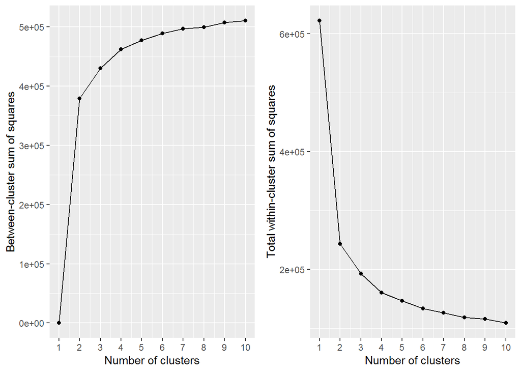

```r
grid.arrange(p3, p4, ncol=2)
```

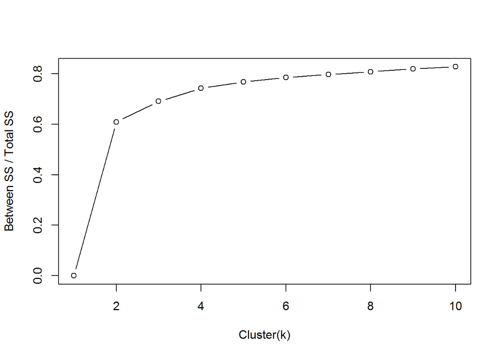

```r
k <-list()
for(i in 1:10){
  k[[i]] <- kmeans(airline_without_text,i)
}


betweennss_totss <- list()
for(i in 1:10){
  betweennss_totss[[i]] <- k[[i]]$betweenss/k[[i]]$totss
}

#type = b to say that we want it to
#be both dots and lines
plot(1:10,betweennss_totss,type="b",
     ylab="Between SS / Total SS",
     xlab = "Cluster(k)")
```

we notice that the best value of k is 3

```r
set.seed(0)
air_k2 <- kmeans(airline_without_text, centers=3)
```

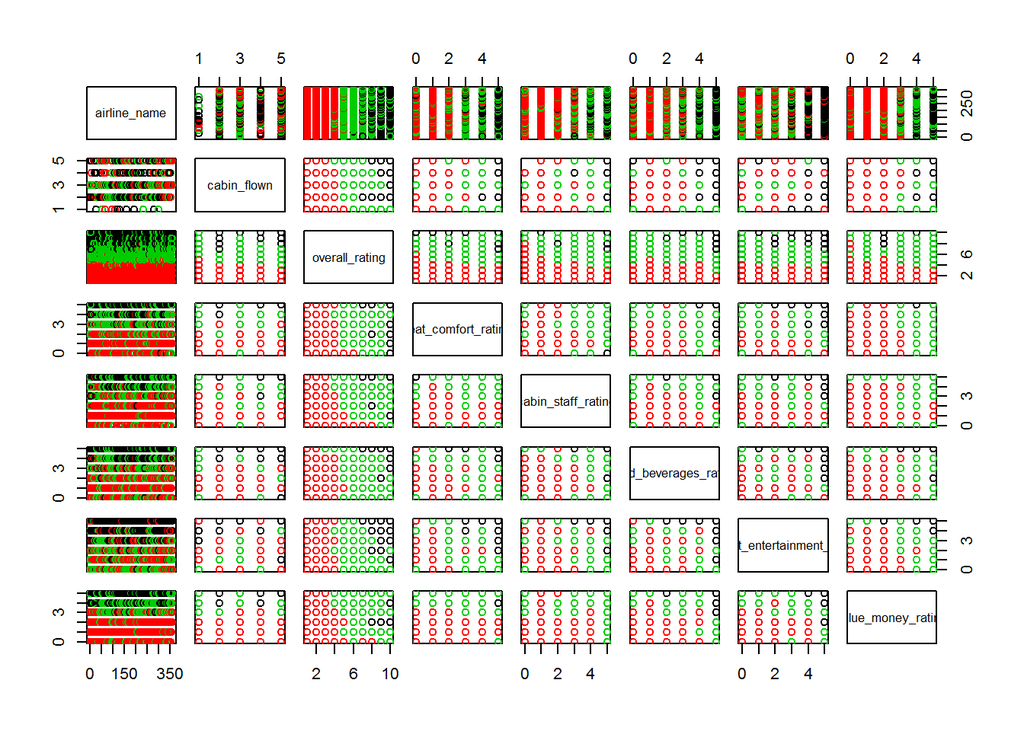

```r
plot(airline_sample,col = air_k2$cluster)
```